# Molluscs only - 200 CS

2023-10-11

## Script to work on analyses for causes paper

##Taxonomic work is needed? # Morpho differentiation types: More CS sl than CS ss overall? # Need to find expectations and test against 50:50 mark

```
##
##  Pearson's Chi-squared test with Yates' continuity correction
##
## data:  cbind(expected, observed)
## X-squared = 4.1855, df = 1, p-value = 0.04077
```

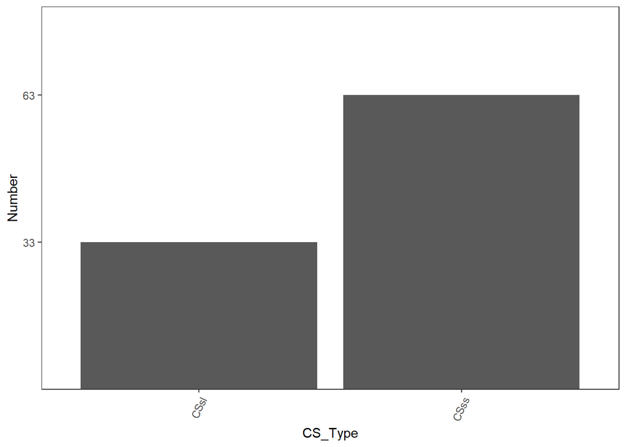

More CSss than the 50% benchmark (significant), so reject the idea that most CS are just due to taxonomic oversight. (This is closer to 0.05 than other subsets!)

# Available technology – More diagnostic differences in species described earlier?

```
##
##        FALSE TRUE
##   1750     2    5
##   1760     1    3
##   1770     1    2
##   1780     1    0
##   1790     1    8
##   1800     2    0
##   1810     1    3
##   1820     5    2
##   1830     3    3
##   1840     2    4
##   1850     0    3
##   1860     2    2
##   1870     0    1
##   1880     1    0
##   1890     1    1
##   1920     0    2
##   1930     1    0
##   1960     1    0
##   1970     1    1
##   1980     1    3
##   1990     1    1
##   2000     1    5
##   2010     0    6
```

```
##
##  Pearson's Chi-squared test
##
## data:  decademorpho$decade and decademorpho$CSss
## X-squared = 27.245, df = 22, p-value = 0.2021
```

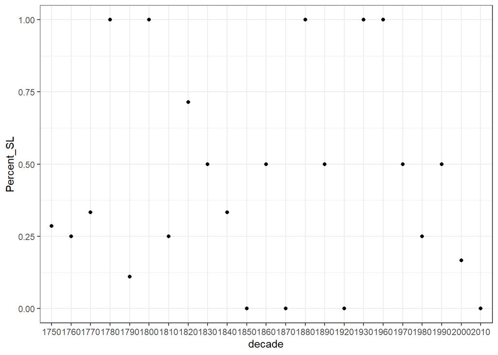

There is no trend in the percent of CSsl (diagnostic differences) through time; hypothesis not supported.

# Prevailing theories of nature and species origins - More CS in fragmented habitats in species described before Darwin?

```
##
##              1 10 100 1000 25  5
##   1756-1859  1 28   7    8 27 25
##   1860-1980  0  6   9    3 10  6
##   1981-2020  0  4  16    0  8  2
```

```
##
##  Pearson's Chi-squared test
##
## data:  breaks_HKK$decade_bin and breaks_HKK$HKK
## X-squared = 35.823, df = 10, p-value = 9.029e-05
```

```
##                     1        10        100       1000        25          5
## pre_Darwin 0.01041667 0.2916667 0.07291667 0.08333333 0.2812500 0.26041667
## pre_Kimura 0.00000000 0.1764706 0.26470588 0.08823529 0.2941176 0.17647059
## modern     0.00000000 0.1333333 0.53333333 0.00000000 0.2666667 0.06666667
```

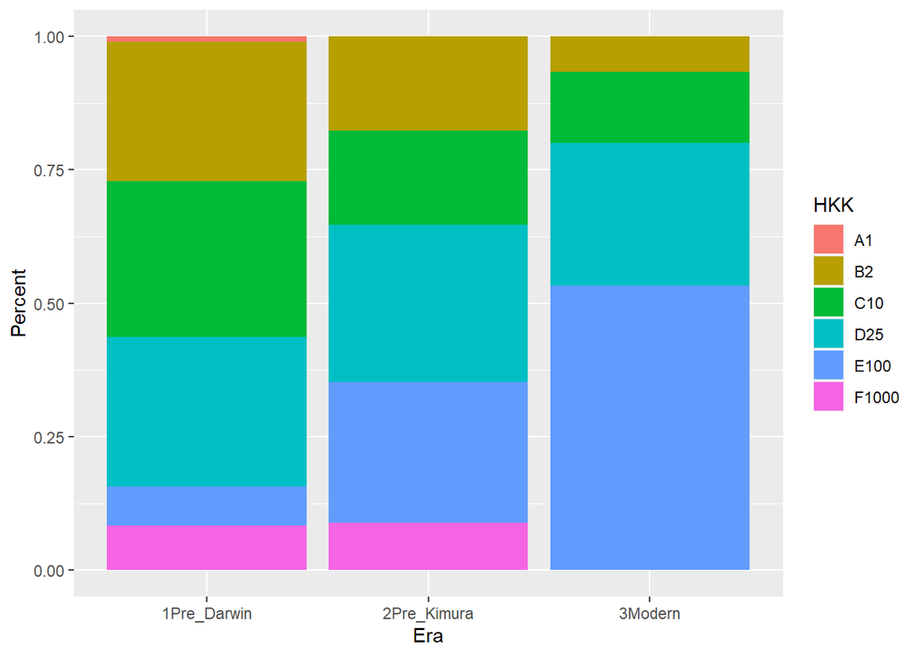

# Accessibility of habitat when species described - Percentage of CS in inaccessible habitats higher in earlier spp?

```
##
##        Difficult Easy Normal
##   1750         2    6      9
##   1760         0    2      3
##   1770         0    2      2
##   1780         0    0      2
##   1790         2    3      8
##   1800         1    2      3
##   1810         1    0      5
##   1820         0    4     12
##   1830         1    4      8
##   1840         1    3      9
##   1850         1    2      6
##   1860         0    3      3
##   1870         1    0      0
##   1880         2    0      6
##   1890         2    2      2
##   1910         0    0      1
##   1920         2    0      2
##   1930         1    0      1
##   1940         0    0      1
##   1960         0    2      1
##   1970         1    0      1
##   1980         9    1      3
##   1990         3    1      3
##   2000         3    2      2
##   2010         1    0      7
```

```
##
##  Pearson's Chi-squared test
##
## data:  decadeAccess$decade and decadeAccess$Access
## X-squared = 67.502, df = 48, p-value = 0.03311
```

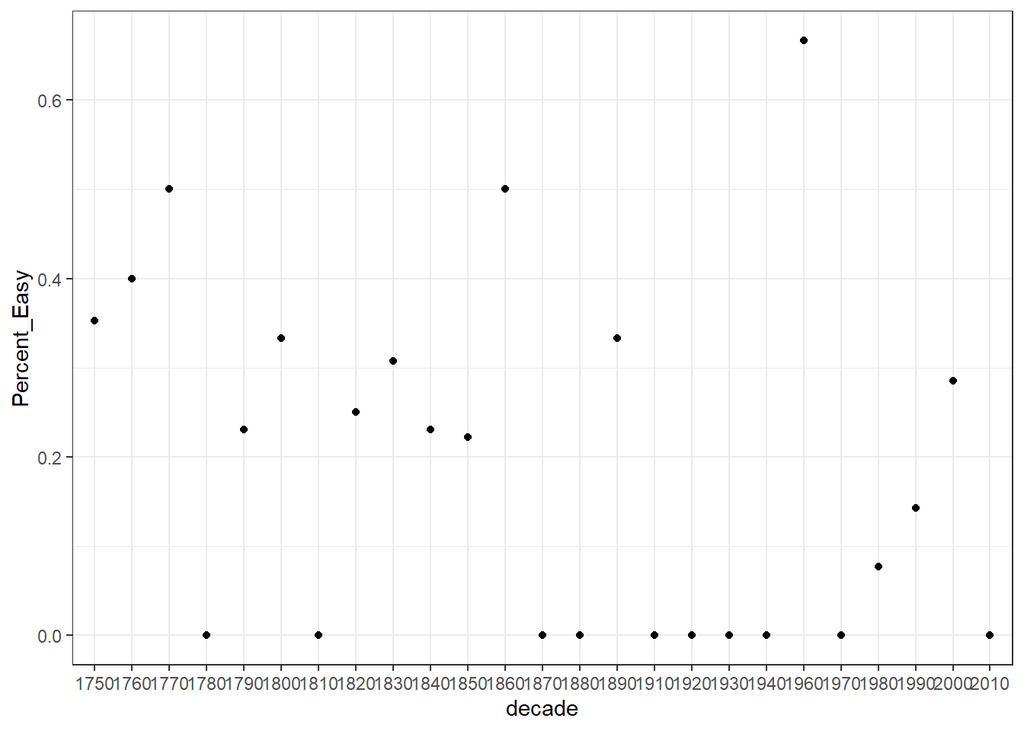

Hypothesis maybe supported? The overall result is significant adn the graph is trending in the right direction, sort of.

## In sum, when we only look at species with CS (i.e. our database), the effect of taxonomic work goes away. This is interesting since that was the strongest effect in paper 1. THIS IS STILL TRUE with the molluscs.

## Effect of recent divergence - dispersal

# Larval type – Planktotrophic/pelagic larvae leads to less CS/NS)?

Note1: for this I’m working with a separate surveylarv input file where I have corrected larval types to pt, lt, dd, and removed all others, including cases where there are multiple types checked. (Most of those cases are where the two CS have different larvae.) This left 112 CS with larval info.

Note2: the data fail the homoscedasticity test (Bartlett’s) so I’ve used a nonparametric Kruskal-Wallis test to see if CS/NS is different among groups.

```
##       DD       LT       PT
## 3.416667 4.666667 3.962963
```

```
##       DD       LT       PT
## 2.418677 6.615490 4.592705
```

```
##
##  Kruskal-Wallis rank sum test
##
## data:  as.numeric(larv_NbCS$Nb_CS) and larv_NbCS$Larv_type
## Kruskal-Wallis chi-squared = 0.10118, df = 2, p-value = 0.9507
```

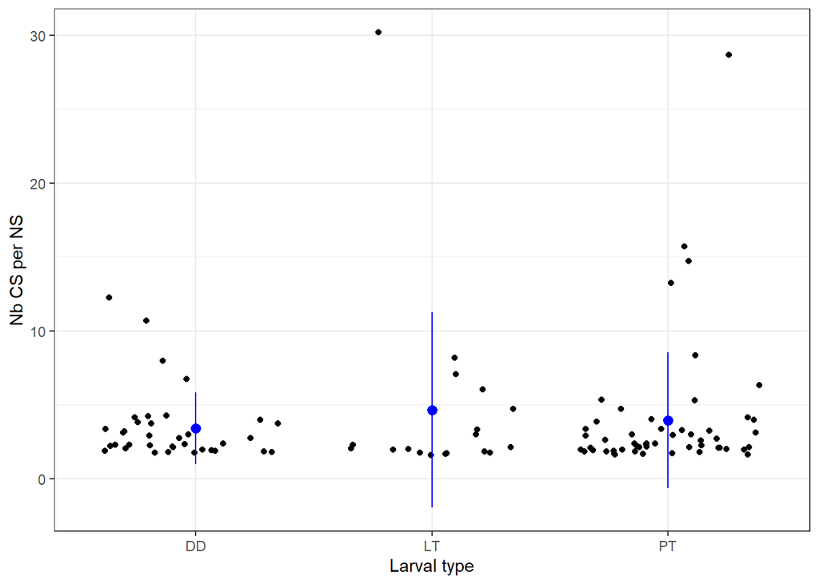

Hypothesis not supported.

# High HKK leads to more CS ss – testing this based on Nb_CS per HKK.

Note: data again failed homoscedasticity, using Kruskal Wallis test

```
##        1        5       10       25      100     1000
## 2.000000 3.868421 4.309524 3.600000 2.600000 3.000000
```

```
##         1         5        10        25       100      1000
##        NA 2.4513764 5.1819955 4.3817805 0.9761871 0.8944272
```

```
##
##  Kruskal-Wallis rank sum test
##
## data:  HKK_NbCS$Nb_CS and HKK_NbCS$HKKv3
## Kruskal-Wallis chi-squared = 7.8684, df = 5, p-value = 0.1636
```

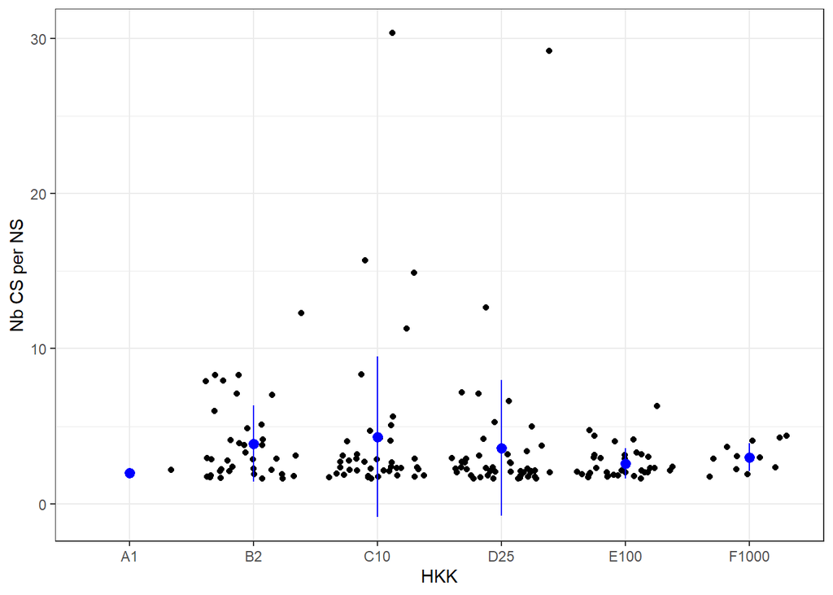

Result: Hypothesis not supported.

## In sum, NO support for the role of recent divergence as measured by a proxy of dispersal when considering only the molluscs.

# More stable environments = more CSss or statistical differences

Note: stable = pelagic, deepsea, cave, coralreef; not stable = coastal, intertidal, estuarine, seagrass

```
##
##         FALSE TRUE
##   FALSE    27    6
##   TRUE     40   23
```

```
##
##  Pearson's Chi-squared test with Yates' continuity correction
##
## data:  stable_hab$CSss and stable_hab$Stable
## X-squared = 2.6353, df = 1, p-value = 0.1045
```

```
##                FALSE      TRUE
## CSss_total 0.5970149 0.7931034
## CSsl_total 0.4029851 0.2068966
```

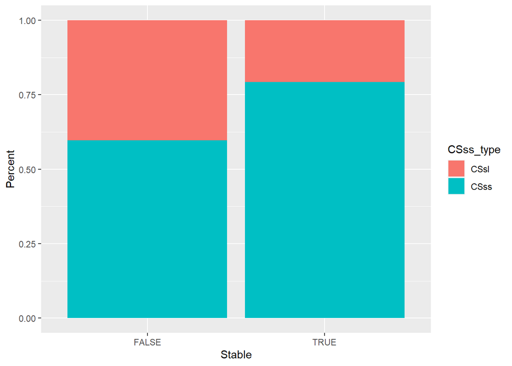

Result: More CSss found in stable environments, but not significant. Trends in direction expected.

# Note also that stabilizing selection predicts more CSss than CSsl, which is what we find (see above).

## In sum, we generally have support for this idea.

## High Ne (neutral hypotheses)

# Reproductive investment - Low reproductive investment leads to more statistical divergence? (Repro. investment proxy for Ne)

Note1: Again this uses the surveylarv dataset with hand cleaning. Note2: Planktotrophic = LOW; Lecithotrophic, Brooding, DD = HIGH; If a spp could be both low and high, have marked it NA (is usually bc the CS have different larval types). Anything else got marked NA to be conservative. Note3: Only 54 cases are considered here, meaning that is where we have morphological data AND larval type data AND Mollusc

```
##
##                      HIGH LOW
##   Diagnostic            8  10
##   No differentiation    9  10
##   Statistic            10   7
```

```
##
##  Pearson's Chi-squared test
##
## data:  surveylarv$Morpho_diff and surveylarv$Repro_invest
## X-squared = 0.80427, df = 2, p-value = 0.6689
```

Result: not significant.

# High HKK leads to more CS ss (HKK as proxy for Ne)

```
##
##                       1  5 10 25 100 1000
##   Diagnostic          0 11  7 11   1    1
##   No differentiation  1  6  7  8  14    0
##   Statistic           0  7  7  5   1    0
```

```
##            1         5        10        25    100 1000
## stat_total 0 0.2916667 0.3333333 0.2083333 0.0625    0
## diag_total 0 0.4583333 0.3333333 0.4583333 0.0625    1
## nod_total  1 0.2500000 0.3333333 0.3333333 0.8750    0
```

```
##
##    1    5   10   25  100 1000
##    1   24   21   24   16    1
```

```
##
##  Pearson's Chi-squared test
##
## data:  surveymorpho$Morpho_diff and surveymorpho$HKKv3
## X-squared = 22.392, df = 10, p-value = 0.01323
```

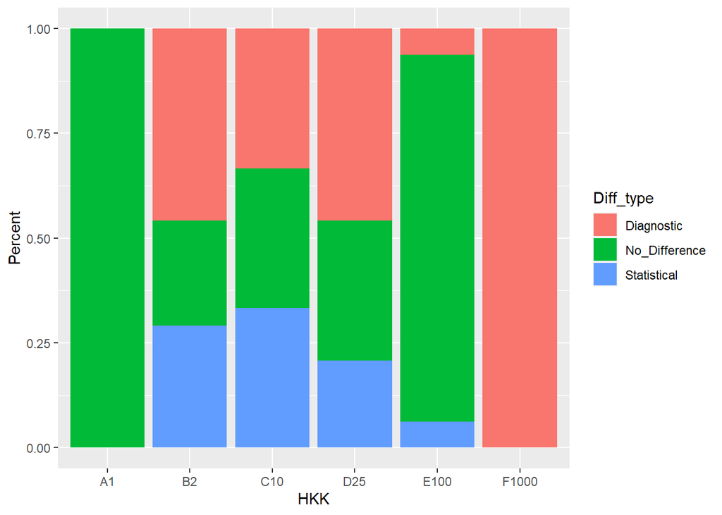

```
##
##        FALSE TRUE
##   1        0    1
##   5       11   13
##   10       7   14
##   25      11   13
##   100      1   15
##   1000     1    0
```

```
##
##  Pearson's Chi-squared test
##
## data:  surveymorpho$HKKv3 and surveymorpho$CSss
## X-squared = 10.609, df = 5, p-value = 0.05971
```

```
##            1         5        10        25    100 1000
## CSss_total 1 0.5416667 0.6666667 0.5416667 0.9375    0
## CSsl_total 0 0.4583333 0.3333333 0.4583333 0.0625    1
```

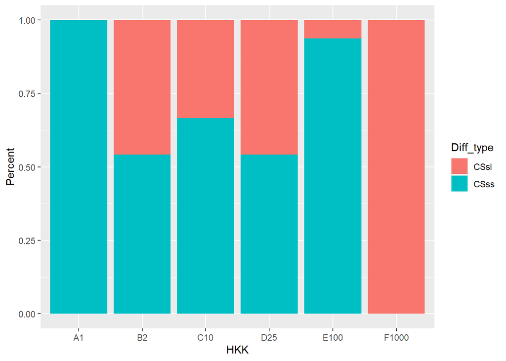

Results: More diagnostic differences (=CSsl) at lower HKK values, both when considering 3 morpho classes AND just ss vs sl; lots of no difference at high HKK. Numbers are very small at 1 and 1000; to be ignored. Overall, this is decent support for the hypothesis.

## In sum, we see support for the neutral hypothesis if we use HKK as a proxy for Ne but NOT if we use reproductive investment.

## Hypothesis: effect of recent divergence – More sympatric than allopatric CS/NS for a given Nsg?

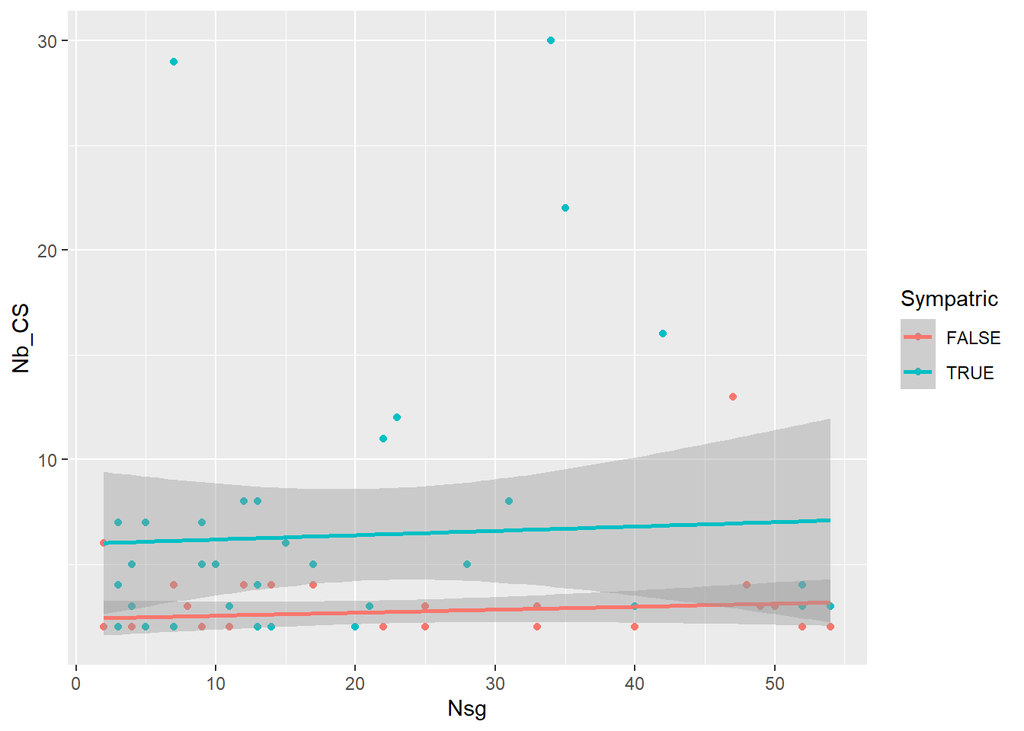

```
## ANOVA Table (type II tests)
##
##      Effect DFn DFd     F     p p<.05   ges
## 1     Nb_CS   1  81 0.307 0.581       0.004
## 2 Sympatric   1  81 0.173 0.678       0.002
```

These results aren’t statistically significant (ANCOVA) but the graph is in line with the hypothesis. Marginal support.

## Selection against hybrids – More diagnostic differences in sympatry than allopatry?

```
##
##         FALSE TRUE
##   FALSE    14    9
##   TRUE     21   19
```

```
##
##  Pearson's Chi-squared test with Yates' continuity correction
##
## data:  surveymorpho$CSss and surveymorpho$Sympatric
## X-squared = 0.14466, df = 1, p-value = 0.7037
```

```
##            FALSE      TRUE
## CSss_total   0.6 0.6785714
## CSsl_total   0.4 0.3214286
```

[figure not shown]

Result: hypothesis not supported, but v small sample sizes here.

## Importance of biological traits

# More diagnostic traits with hard skeleton?

```
##
##                       N  Y
##   Diagnostic          0 33
##   No differentiation  0 37
##   Statistic           0 26
```

```
##              N         Y
## stat_total NaN 0.2708333
## diag_total NaN 0.3437500
## nod_total  NaN 0.3854167
```

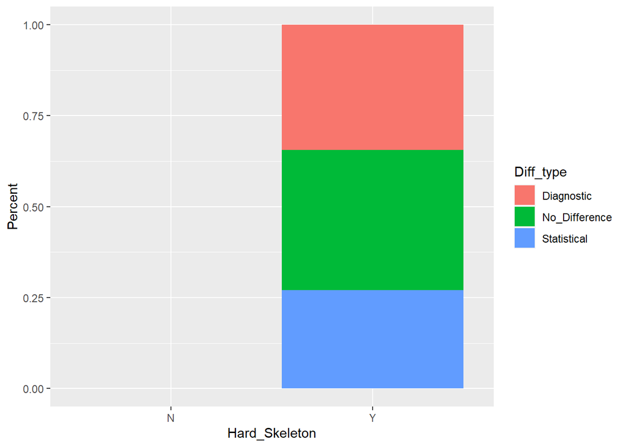

Everyone has a hard skeleton, so no test.

# More diagnostic traits with image vision?

```
##
##                       N  Y
##   Diagnostic          2 31
##   No differentiation  6 31
##   Statistic           8 18
```

```
##
##  Pearson's Chi-squared test
##
## data:  surveymorpho$Morpho_diff and surveymorpho$image
## X-squared = 6.4012, df = 2, p-value = 0.04074
```

```
##                N      Y
## stat_total 0.500 0.2250
## diag_total 0.125 0.3875
## nod_total  0.375 0.3875
```

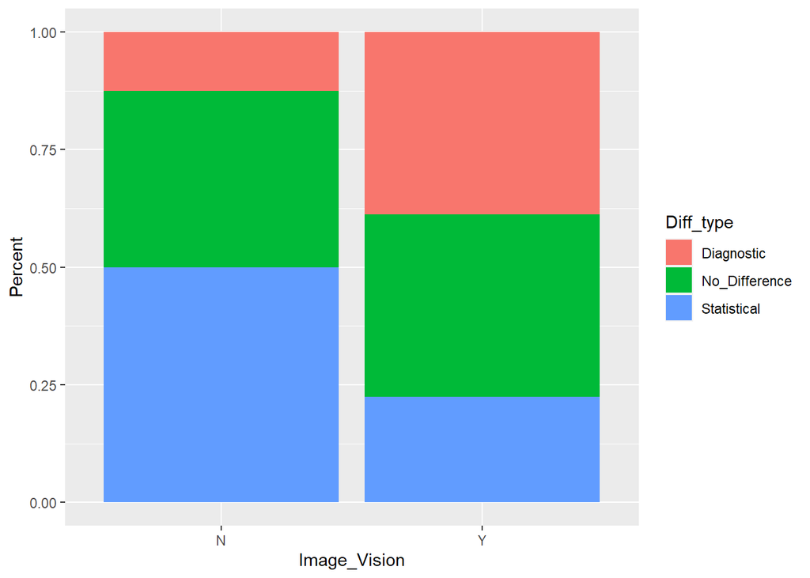

Result: more diagnostic differences with image vision; hypothesis supported. Might this also be confounded with class somehow?

# More diagnostic traits with internal fertilization?

```
##
##                       B  E  I
##   Diagnostic         30  2  1
##   No differentiation 30  6  1
##   Statistic          16  8  2
```

```
##
##  Pearson's Chi-squared test
##
## data:  surveymorpho$Morpho_diff and surveymorpho$ferti
## X-squared = 8.015, df = 4, p-value = 0.09103
```

```
##                    B     E    I
## stat_total 0.2105263 0.500 0.50
## diag_total 0.3947368 0.125 0.25
## nod_total  0.3947368 0.375 0.25
```

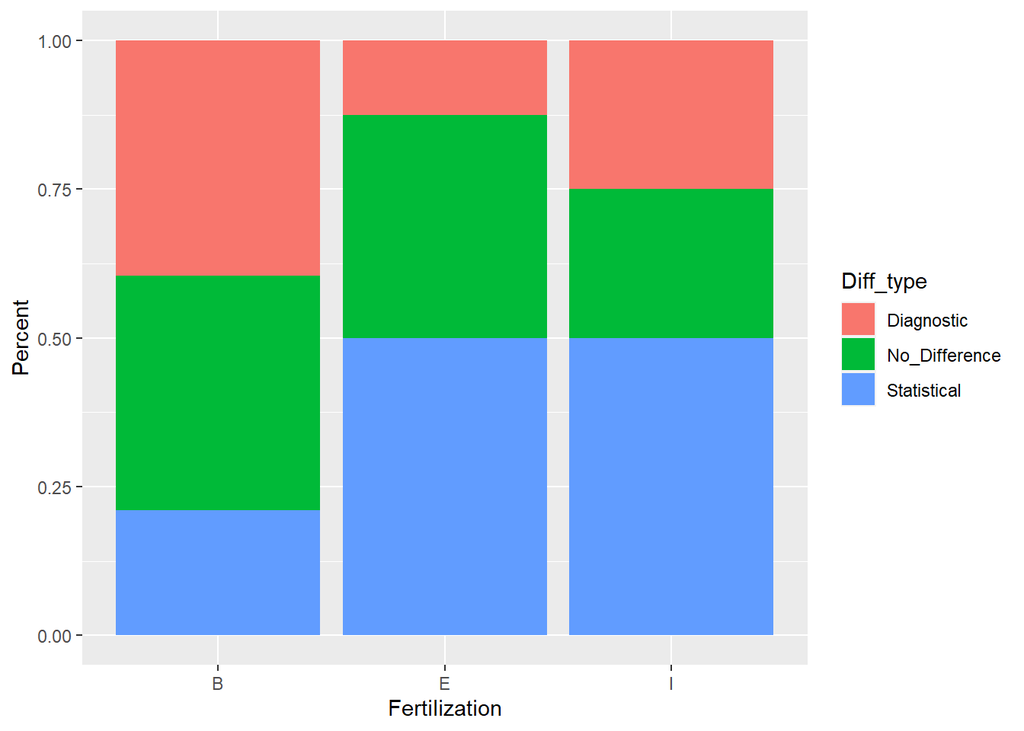

Result: hypothesis not really supported. The gastropods are the largest thing in this dataset and are weighing heavily, with “both” and more diagnostic differences. Perhaps investigate further.

# More diagnostic traits with external genitalia?

```
##
##                       B  N  Y
##   Diagnostic         30  2  1
##   No differentiation 30  6  1
##   Statistic          16  8  2
```

```
##
##  Pearson's Chi-squared test
##
## data:  surveymorpho$Morpho_diff and surveymorpho$genitals
## X-squared = 8.015, df = 4, p-value = 0.09103
```

```
##                    B     N    Y
## stat_total 0.2105263 0.500 0.50
## diag_total 0.3947368 0.125 0.25
## nod_total  0.3947368 0.375 0.25
```

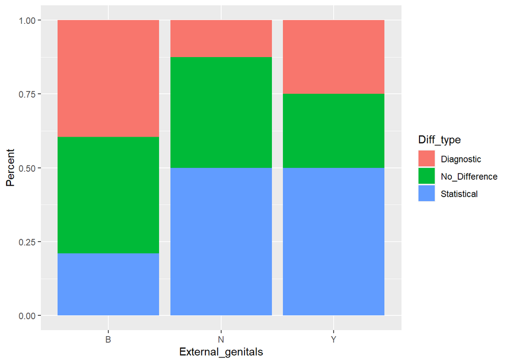

Result: Same as above; results here are heavily tilted towards the gastropods.

## In sum, biological traits still have a role in determining the TYPE of CS that is found (ss vs sl) BUT this may be partially confounded by class.

## So, overall conclusions: When looking at just the molluscs, most patterns are similar to the whole dataset. Most notably, we now have support for image vision. Of note: more molluscs in the dataset than any other phylum.